# Project: Investigate a Dataset - [TMDB Movies Dataset]

- Questions for Analysis
- Introduction
- Data Wrangling
- Exploratory Data Analysis
- Conclusions

## Question(s) for Analysis

#### Question 1: How have revenue and budget changed over the years?

#### Question 2: How does genre affect popularity?

## Introduction

### Dataset Description

> The TMDB dataset is a comprehensive movie database available online at https://www.themoviedb.org/ It contains a vast amount of data on movies, TV shows, actors, and awards.

## Install packages.

> If some of the code does not work, you may not have the required packages installed. In that case, uncomment the following cell and run it. It is commented out by default to avoid the extra runtime caused by trying to install them.

```python
# %pip install pandas
# %pip install numpy
# %pip install matplotlib
```

```python
# Import the required packages for this notebook.
import pandas as pd
import numpy as np
import matplotlib.pyplot as plt
```

```python
# Import the dataset to be used and show the first few rows.
df = pd.read_csv('tmdb-movies.csv')
df.head()
```

|  | id | imdb_id | popularity | budget | revenue | original_title | cast | homepage | director | tagline | ... | overview | runtime | genres | production_companies | release_date | vote_count | vote_average | release_year | budget_adj | revenue_adj |
| --- | --- | --- | --- | --- | --- | --- | --- | --- | --- | --- | --- | --- | --- | --- | --- | --- | --- | --- | --- | --- | --- |
| 0 | 135397 | tt0369610 | 32.985763 | 150000000 | 1513528810 | Jurassic World | Chris Pratt\|Bryce Dallas Howard\|Irrfan Khan\|Vi... | http://www.jurassicworld.com/ | Colin Trevorrow | The park is open. | ... | Twenty-two years after the events of Jurassic ... | 124 | Action\|Adventure\|Science Fiction\|Thriller | Universal Studios\|Amblin Entertainment\|Legenda... | 6/9/15 | 5562 | 6.5 | 2015 | 1.379999e+08 | 1.392446e+09 |
| 1 | 76341 | tt1392190 | 28.419936 | 150000000 | 378436354 | Mad Max: Fury Road | Tom Hardy\|Charlize Theron\|Hugh Keays-Byrne\|Nic... | http://www.madmaxmovie.com/ | George Miller | What a Lovely Day. | ... | An apocalyptic story set in the furthest reach... | 120 | Action\|Adventure\|Science Fiction\|Thriller | Village Roadshow Pictures\|Kennedy Miller Produ... | 5/13/15 | 6185 | 7.1 | 2015 | 1.379999e+08 | 3.481613e+08 |
| 2 | 262500 | tt2908446 | 13.112507 | 110000000 | 295238201 | Insurgent | Shailene Woodley\|Theo James\|Kate Winslet\|Ansel... | http://www.thedivergentseries.movie/#insurgent | Robert Schwentke | One Choice Can Destroy You | ... | Beatrice Prior must confront her inner demons ... | 119 | Adventure\|Science Fiction\|Thriller | Summit Entertainment\|Mandeville Films\|Red Wago... | 3/18/15 | 2480 | 6.3 | 2015 | 1.012000e+08 | 2.716190e+08 |
| 3 | 140607 | tt2488496 | 11.173104 | 200000000 | 2068178225 | Star Wars: The Force Awakens | Harrison Ford\|Mark Hamill\|Carrie Fisher\|Adam D... | http://www.starwars.com/films/star-wars-episod... | J.J. Abrams | Every generation has a story. | ... | Thirty years after defeating the Galactic Empi... | 136 | Action\|Adventure\|Science Fiction\|Fantasy | Lucasfilm\|Truenorth Productions\|Bad Robot | 12/15/15 | 5292 | 7.5 | 2015 | 1.839999e+08 | 1.902723e+09 |
| 4 | 168259 | tt2820852 | 9.335014 | 190000000 | 1506249360 | Furious 7 | Vin Diesel\|Paul Walker\|Jason Statham\|Michelle ... | http://www.furious7.com/ | James Wan | Vengeance Hits Home | ... | Deckard Shaw seeks revenge against Dominic Tor... | 137 | Action\|Crime\|Thriller | Universal Pictures\|Original Film\|Media Rights ... | 4/1/15 | 2947 | 7.3 | 2015 | 1.747999e+08 | 1.385749e+09 |

5 rows × 21 columns

```python
# Check some initial statistical values for the dataset
df.describe()
```

|  | id | popularity | budget | revenue | runtime | vote_count | vote_average | release_year | budget_adj | revenue_adj |
| --- | --- | --- | --- | --- | --- | --- | --- | --- | --- | --- |
| count | 10866.000000 | 10866.000000 | 1.086600e+04 | 1.086600e+04 | 10866.000000 | 10866.000000 | 10866.000000 | 10866.000000 | 1.086600e+04 | 1.086600e+04 |
| mean | 66064.177434 | 0.646441 | 1.462570e+07 | 3.982332e+07 | 102.070863 | 217.389748 | 5.974922 | 2001.322658 | 1.755104e+07 | 5.136436e+07 |
| std | 92130.136561 | 1.000185 | 3.091321e+07 | 1.170035e+08 | 31.381405 | 575.619058 | 0.935142 | 12.812941 | 3.430616e+07 | 1.446325e+08 |
| min | 5.000000 | 0.000065 | 0.000000e+00 | 0.000000e+00 | 0.000000 | 10.000000 | 1.500000 | 1960.000000 | 0.000000e+00 | 0.000000e+00 |
| 25% | 10596.250000 | 0.207583 | 0.000000e+00 | 0.000000e+00 | 90.000000 | 17.000000 | 5.400000 | 1995.000000 | 0.000000e+00 | 0.000000e+00 |
| 50% | 20669.000000 | 0.383856 | 0.000000e+00 | 0.000000e+00 | 99.000000 | 38.000000 | 6.000000 | 2006.000000 | 0.000000e+00 | 0.000000e+00 |
| 75% | 75610.000000 | 0.713817 | 1.500000e+07 | 2.400000e+07 | 111.000000 | 145.750000 | 6.600000 | 2011.000000 | 2.085325e+07 | 3.369710e+07 |
| max | 417859.000000 | 32.985763 | 4.250000e+08 | 2.781506e+09 | 900.000000 | 9767.000000 | 9.200000 | 2015.000000 | 4.250000e+08 | 2.827124e+09 |

> It seems there are a lot of films with values of 0 for budget and revenue, as well as at least one with 0 for runtime. In fact, it seems that at least 50% of all films in the dataset have a budget or revenue of 0.

```python
df[df['runtime'] == 0].head()
```

|  | id | imdb_id | popularity | budget | revenue | original_title | cast | homepage | director | tagline | ... | overview | runtime | genres | production_companies | release_date | vote_count | vote_average | release_year | budget_adj | revenue_adj |
| --- | --- | --- | --- | --- | --- | --- | --- | --- | --- | --- | --- | --- | --- | --- | --- | --- | --- | --- | --- | --- | --- |
| 92 | 370687 | tt3608646 | 1.876037 | 0 | 0 | Mythica: The Necromancer | Melanie Stone\|Adam Johnson\|Kevin Sorbo\|Nicola ... | http://www.mythicamovie.com/#!blank/y9ake | A. Todd Smith | NaN | ... | Mallister takes Thane prisoner and forces Mare... | 0 | Fantasy\|Action\|Adventure | Arrowstorm Entertainment\|Camera 40 Productions... | 12/19/15 | 11 | 5.4 | 2015 | 0.0 | 0.0 |
| 334 | 361931 | tt5065822 | 0.357654 | 0 | 0 | Ronaldo | Cristiano Ronaldo | http://www.ronaldothefilm.com | Anthony Wonke | Astonishing. Intimate. Definitive. | ... | Filmed over 14 months with unprecedented acces... | 0 | Documentary | On The Corner Films\|We Came, We Saw, We Conque... | 11/9/15 | 80 | 6.5 | 2015 | 0.0 | 0.0 |
| 410 | 339342 | tt2948712 | 0.097514 | 0 | 0 | Anarchy Parlor | Robert LaSardo\|Jordan James Smith\|Sara Fabel\|T... | NaN | Kenny Gage\|Devon Downs | NaN | ... | Six young college hopefuls vacationing and par... | 0 | Horror | NaN | 1/1/15 | 15 | 5.6 | 2015 | 0.0 | 0.0 |
| 445 | 353345 | tt3800796 | 0.218528 | 0 | 0 | The Exorcism of Molly Hartley | Sarah Lind\|Devon Sawa\|Gina Holden\|Peter MacNei... | NaN | Steven R. Monroe | NaN | ... | Taking place years after The Haunting of Molly... | 0 | Horror | WT Canada Productions | 10/9/15 | 52 | 5.0 | 2015 | 0.0 | 0.0 |
| 486 | 333653 | tt4058368 | 0.176744 | 0 | 0 | If There Be Thorns | Heather Graham\|Jason Lewis\|Rachael Carpani\|Mas... | NaN | Nancy Savoca | NaN | ... | The third installment in V.C. Andrewsâ€™ bests... | 0 | TV Movie\|Drama | A+E Studios\|Jane Startz Productions | 4/5/15 | 11 | 5.4 | 2015 | 0.0 | 0.0 |

5 rows × 21 columns

> It seems that a lot of the "zero" entries are just incomplete data. This will probably affect analysis in a negative way, so it will likely be necessary to get rid of them. If it's only a small amount, I could probably just add the data manually.

```python
print((df['runtime'] == 0).sum())
print((df['revenue'] == 0).sum())
print((df['budget'] == 0).sum())
```

```
31
6016
5696
```

> That is not a small amount. As such, it is probably best to just remove the entries with the incomplete revenue, budget, and runtime. This does mean that we will need to get rid of at least 6000 entries, however. For analysis of revenue and budget, these entries will cause issues. However, for the analysis of genre and popularity, these entries may still have adequate data. As such, I will clean the dataset first, then create a separate dataset without the zero revenue or budget entries.

## Data Wrangling

### General Properties

```python
df.shape
```

```
(10866, 21)
```

```python
# Check for columns with null values and check data types
df.info()
```

```
<class 'pandas.core.frame.DataFrame'>
RangeIndex: 10866 entries, 0 to 10865
Data columns (total 21 columns):
 #   Column                Non-Null Count  Dtype
---  ------                --------------  -----
 0   id                    10866 non-null  int64
 1   imdb_id               10856 non-null  object
 2   popularity            10866 non-null  float64
 3   budget                10866 non-null  int64
 4   revenue               10866 non-null  int64
 5   original_title        10866 non-null  object
 6   cast                  10790 non-null  object
 7   homepage              2936 non-null   object
 8   director              10822 non-null  object
 9   tagline               8042 non-null   object
 10  keywords              9373 non-null   object
 11  overview              10862 non-null  object
 12  runtime               10866 non-null  int64
 13  genres                10843 non-null  object
 14  production_companies  9836 non-null   object
 15  release_date          10866 non-null  object
 16  vote_count            10866 non-null  int64
 17  vote_average          10866 non-null  float64
 18  release_year          10866 non-null  int64
 19  budget_adj            10866 non-null  float64
 20  revenue_adj           10866 non-null  float64
dtypes: float64(4), int64(6), object(11)
memory usage: 1.7+ MB
```

```python
# release_date represents a date, but is listed as an object dtype. Check the actual data type being used in the column.
print(type(df['release_date'][0]))
```

```
<class 'str'>
```

> Pandas loads numeric data types as numeric64 by default. However, this causes the dataframe to use far more memory than necessary. The dataset also contains many null values in the non-numeric columns. If they were in numeric columns, various methods could be used to replace the null values with real values, such as by using values of central tendency (mean, median, mode). Because they aren't in numeric columns, they will likely just need to be removed. This will also be done in the data cleaning section.

> Before we start cleaning, I want to prepare a way to reduce the size of the dataset to reduce memory usage. The first thing to do is check the maximum numeric values to later change those columns to smaller numeric types.

```python
# Check maximum values in dataset
df.max(numeric_only=True)
```

```
id              4.178590e+05
popularity      3.298576e+01
budget          4.250000e+08
revenue         2.781506e+09
runtime         9.000000e+02
vote_count      9.767000e+03
vote_average    9.200000e+00
release_year    2.015000e+03
budget_adj      4.250000e+08
revenue_adj     2.827124e+09
dtype: float64
```

```python
# Takes a dataframe and creates a mask dict to change numeric columns to their lowest possible numeric type (i.e. int64 may become int32, int16, or
# int8). Pandas has a .numeric() method, but the "downcast" argument seems to only allow for either int or float, so different lists would have to
# be created for both dtypes, then the method would have be called on both lists. Basically, the creation of a new function and using the pandas method
# would both create fairly complex code, and this code was already created before I learned about the method, so this is the one I chose.

def lowest_num(dataset):
    """
    Accepts pandas dataframe as singular argument.
    Prints python dict containing the dataset's numeric columns along with the smallest numeric datatype that the column allows for.
    Returns mask dictionary for typing pandas dataframe with .astype() method

    The way the function creates the mask is by first finding the maximum value in each numeric column. Then, it finds the base2 log of each maximum,
    finds the next highest power of two, and adds the name of the column and that power of two as a key-value pair to the mask dict.
    """
    # Create list of max values in each column and list of numeric columns.
    max_values = dataset.max(numeric_only=True).to_list()
    max_mask = {}
    num_cols = dataset.select_dtypes(include='number').columns.tolist()
    # ind is used for indexing each list, to avoid the issue of to columns having the same max value. The for loop could also loop through the list
    # of columns, but I thought of this solution first.
    ind = 0

    # Loop through all of the max values. For each value, find the base2 log; find the next highest power of two; add column_name: power_of_two to
    # mask dict.
    for val in max_values:
        log2_val = np.ceil(np.log2(val))
        # Pandas dataframes only support a minimum float size of 16 bits, so if the next highest power of two is 8, typing a column as float8 will
        # cause an error.
        if str(dataset[num_cols[ind]].dtype)[0] == 'f' and log2_val < 16:
            log2_val = 16
        # Integers have a smallest size of 8.
        if str(dataset[num_cols[ind]].dtype)[0] == 'i' and log2_val < 8:
            log2_val = 8
        max_mask[num_cols[ind]] = str(dataset[num_cols[ind]].dtype)[:-2] + str(int(2**np.ceil(np.log2(log2_val))))
        ind += 1

    # print(max_mask)
    return max_mask
```

```python
# Use the function to create mask for resizing the dataframe for improved memory performance.
typing_mask = lowest_num(df)
```

> I originally created the function to do the same thing to both the original dataframe and the no zeros dataframe, only to realize that both dataframes would have the same mask, so calling the function on both dataframes wouldn't actually make any sense. Oh well.

> Next is to check for duplicate rows.

```python
sum(df.duplicated())
```

```
1
```

```python
df[df.duplicated() == True]
```

|  | id | imdb_id | popularity | budget | revenue | original_title | cast | homepage | director | tagline | ... | overview | runtime | genres | production_companies | release_date | vote_count | vote_average | release_year | budget_adj | revenue_adj |
| --- | --- | --- | --- | --- | --- | --- | --- | --- | --- | --- | --- | --- | --- | --- | --- | --- | --- | --- | --- | --- | --- |
| 2090 | 42194 | tt0411951 | 0.59643 | 30000000 | 967000 | TEKKEN | Jon Foo\|Kelly Overton\|Cary-Hiroyuki Tagawa\|Ian... | NaN | Dwight H. Little | Survival is no game | ... | In the year of 2039, after World Wars destroy ... | 92 | Crime\|Drama\|Action\|Thriller\|Science Fiction | Namco\|Light Song Films | 3/20/10 | 110 | 5.0 | 2010 | 30000000.0 | 967000.0 |

1 rows × 21 columns

> There is only one duplicated row. This will be removed early on in the cleaning section.

```python
df.nunique()
```

```
id                      10865
imdb_id                 10855
popularity              10814
budget                    557
revenue                  4702
original_title          10571
cast                    10719
homepage                 2896
director                 5067
tagline                  7997
keywords                 8804
overview                10847
runtime                   247
genres                   2039
production_companies     7445
release_date             5909
vote_count               1289
vote_average               72
release_year               56
budget_adj               2614
revenue_adj              4840
dtype: int64
```

> Another way to reduce memory usage is by changing low-cardinality fields to a category data type. Changing the 'genre' field may work.

### Data Cleaning

```python
# Removing duplicates
df.drop_duplicates(inplace=True)
sum(df.duplicated())
```

```
0
```

```python
# Ran before and after next two cells to see difference
df.dtypes
```

```
id                        int64
imdb_id                  object
popularity              float64
budget                    int64
revenue                   int64
original_title           object
cast                     object
homepage                 object
director                 object
tagline                  object
keywords                 object
overview                 object
runtime                   int64
genres                   object
production_companies     object
release_date             object
vote_count                int64
vote_average            float64
release_year              int64
budget_adj              float64
revenue_adj             float64
dtype: object
```

```python
# Use the typing_mask variable to change numeric datatypes to smaller numeric types.
df = df.astype(typing_mask)
```

```python
# Confirm change and check dataframe size.
df.info()
```

```
<class 'pandas.core.frame.DataFrame'>
Index: 10865 entries, 0 to 10865
Data columns (total 21 columns):
 #   Column                Non-Null Count  Dtype
---  ------                --------------  -----
 0   id                    10865 non-null  int32
 1   imdb_id               10855 non-null  object
 2   popularity            10865 non-null  float16
 3   budget                10865 non-null  int32
 4   revenue               10865 non-null  int32
 5   original_title        10865 non-null  object
 6   cast                  10789 non-null  object
 7   homepage              2936 non-null   object
 8   director              10821 non-null  object
 9   tagline               8041 non-null   object
 10  keywords              9372 non-null   object
 11  overview              10861 non-null  object
 12  runtime               10865 non-null  int16
 13  genres                10842 non-null  object
 14  production_companies  9835 non-null   object
 15  release_date          10865 non-null  object
 16  vote_count            10865 non-null  int16
 17  vote_average          10865 non-null  float16
 18  release_year          10865 non-null  int16
 19  budget_adj            10865 non-null  float32
 20  revenue_adj           10865 non-null  float32
dtypes: float16(2), float32(2), int16(3), int32(3), object(11)
memory usage: 1.3+ MB
```

> The change seems to have worked, and it reduced the size from 1.7+ MB to 1.3+ MB. Next, I want to check how changing the 'genres' field affects the dataset.

```python
# Change genre column to category type.
df = df.astype({'genres': 'category'})
```

```python
df.info()
```

```
<class 'pandas.core.frame.DataFrame'>
Index: 10865 entries, 0 to 10865
Data columns (total 21 columns):
 #   Column                Non-Null Count  Dtype
---  ------                --------------  -----
 0   id                    10865 non-null  int32
 1   imdb_id               10855 non-null  object
 2   popularity            10865 non-null  float16
 3   budget                10865 non-null  int32
 4   revenue               10865 non-null  int32
 5   original_title        10865 non-null  object
 6   cast                  10789 non-null  object
 7   homepage              2936 non-null   object
 8   director              10821 non-null  object
 9   tagline               8041 non-null   object
 10  keywords              9372 non-null   object
 11  overview              10861 non-null  object
 12  runtime               10865 non-null  int16
 13  genres                10842 non-null  category
 14  production_companies  9835 non-null   object
 15  release_date          10865 non-null  object
 16  vote_count            10865 non-null  int16
 17  vote_average          10865 non-null  float16
 18  release_year          10865 non-null  int16
 19  budget_adj            10865 non-null  float32
 20  revenue_adj           10865 non-null  float32
dtypes: category(1), float16(2), float32(2), int16(3), int32(3), object(10)
memory usage: 1.3+ MB
```

> This doesn't seem to have changed the size much. Let's get a more in depth view of which data type is best for 'genres'.

```python
df['genres'].memory_usage()
```

```
191050
```

```python
df = df.astype({'genres': 'string'})
df['genres'].memory_usage()
```

```
173840
```

> Keeping 'genres' as string seems to use less memory, so that's how I'll keep it.  
> Looking back on an earlier cell where `df.head()` was called, the reason there are so many different values in the genre column is probably because each film has a set of multiple genres, and there are a little over 2000 unique sets of genres, not 2000 genres.

> Next, I want to change the 'release_date' field to a datetime format, rather than string.

```python
# Changin release_date to a datetime object
df['release_date'] = pd.to_datetime(df['release_date'], format='%m/%d/%y')
df.info()
print(type(df['release_date'][0]))
```

```
<class 'pandas.core.frame.DataFrame'>
Index: 10865 entries, 0 to 10865
Data columns (total 21 columns):
 #   Column                Non-Null Count  Dtype
---  ------                --------------  -----
 0   id                    10865 non-null  int32
 1   imdb_id               10855 non-null  object
 2   popularity            10865 non-null  float16
 3   budget                10865 non-null  int32
 4   revenue               10865 non-null  int32
 5   original_title        10865 non-null  object
 6   cast                  10789 non-null  object
 7   homepage              2936 non-null   object
 8   director              10821 non-null  object
 9   tagline               8041 non-null   object
 10  keywords              9372 non-null   object
 11  overview              10861 non-null  object
 12  runtime               10865 non-null  int16
 13  genres                10842 non-null  string
 14  production_companies  9835 non-null   object
 15  release_date          10865 non-null  datetime64[ns]
 16  vote_count            10865 non-null  int16
 17  vote_average          10865 non-null  float16
 18  release_year          10865 non-null  int16
 19  budget_adj            10865 non-null  float32
 20  revenue_adj           10865 non-null  float32
dtypes: datetime64[ns](1), float16(2), float32(2), int16(3), int32(3), object(9), string(1)
memory usage: 1.3+ MB
<class 'pandas._libs.tslibs.timestamps.Timestamp'>
```

```python
# Check to confirm minimum and maximum dates
print(df['release_date'].min(), df['release_date'].max())
```

```
1969-01-01 00:00:00 2068-12-22 00:00:00
```

```python
# Various films from before 1969 have release dates set in the future.
df[df['release_date'] > pd.to_datetime(2030, format='%Y')]
```

|  | id | imdb_id | popularity | budget | revenue | original_title | cast | homepage | director | tagline | ... | overview | runtime | genres | production_companies | release_date | vote_count | vote_average | release_year | budget_adj | revenue_adj |
| --- | --- | --- | --- | --- | --- | --- | --- | --- | --- | --- | --- | --- | --- | --- | --- | --- | --- | --- | --- | --- | --- |
| 9719 | 62 | tt0062622 | 3.308594 | 12000000 | 56715371 | 2001: A Space Odyssey | Keir Dullea\|Douglas Rain\|Gary Lockwood\|William... | NaN | Stanley Kubrick | An epic drama of adventure and exploration | ... | Humanity finds a mysterious object buried bene... | 149 | Science Fiction\|Mystery\|Adventure | Stanley Kubrick Productions\|Metro-Goldwyn-Maye... | 2068-04-05 | 1708 | 7.699219 | 1968 | 7.522756e+07 | 355546592.0 |
| 9720 | 871 | tt0063442 | 1.153320 | 5800000 | 33395426 | Planet of the Apes | Charlton Heston\|Roddy McDowall\|Kim Hunter\|Maur... | NaN | Franklin J. Schaffner | Somewhere in the Universe, there must be somet... | ... | Taylor and two other astronauts come out of de... | 112 | Adventure\|Science Fiction\|Mystery | Twentieth Century Fox Film Corporation\|APJAC P... | 2068-02-07 | 469 | 7.199219 | 1968 | 3.635999e+07 | 209354704.0 |
| 9721 | 10331 | tt0063350 | 1.058594 | 114000 | 0 | Night of the Living Dead | Duane Jones\|Judith O'Dea\|Karl Hardman\|Marilyn ... | NaN | George A. Romero | If it doesn't scare you, you're already dead! | ... | A group of people try to survive an attack of ... | 96 | Horror | Laurel Group\|Off Color Films\|Image Ten\|Market ... | 2068-10-01 | 279 | 7.199219 | 1968 | 7.146619e+05 | 0.0 |
| 9722 | 26690 | tt0062755 | 0.891113 | 0 | 0 | The Boston Strangler | Tony Curtis\|Henry Fonda\|George Kennedy\|Mike Ke... | NaN | Richard Fleischer | NaN | ... | Boston is being terrorized by a series of seem... | 116 | Crime\|Drama\|Mystery\|Thriller | Twentieth Century Fox Film Corporation | 2068-10-08 | 15 | 6.601562 | 1968 | 0.000000e+00 | 0.0 |
| 9723 | 8069 | tt0062711 | 0.867188 | 0 | 0 | Barbarella | Jane Fonda\|John Phillip Law\|Anita Pallenberg\|M... | NaN | Roger Vadim | See Barbarella do her thing! | ... | In the far future, a highly sexual woman is ta... | 98 | Science Fiction | Dino de Laurentiis Cinematografica\|Marianne Pr... | 2068-10-10 | 63 | 5.398438 | 1968 | 0.000000e+00 | 0.0 |
| ... | ... | ... | ... | ... | ... | ... | ... | ... | ... | ... | ... | ... | ... | ... | ... | ... | ... | ... | ... | ... | ... |
| 10861 | 21 | tt0060371 | 0.080627 | 0 | 0 | The Endless Summer | Michael Hynson\|Robert August\|Lord 'Tally Ho' B... | NaN | Bruce Brown | NaN | ... | The Endless Summer, by Bruce Brown, is one of ... | 95 | Documentary | Bruce Brown Films | 2066-06-15 | 11 | 7.398438 | 1966 | 0.000000e+00 | 0.0 |
| 10862 | 20379 | tt0060472 | 0.065552 | 0 | 0 | Grand Prix | James Garner\|Eva Marie Saint\|Yves Montand\|Tosh... | NaN | John Frankenheimer | Cinerama sweeps YOU into a drama of speed and ... | ... | Grand Prix driver Pete Aron is fired by his te... | 176 | Action\|Adventure\|Drama | Cherokee Productions\|Joel Productions\|Douglas ... | 2066-12-21 | 20 | 5.699219 | 1966 | 0.000000e+00 | 0.0 |
| 10863 | 39768 | tt0060161 | 0.065125 | 0 | 0 | Beregis Avtomobilya | Innokentiy Smoktunovskiy\|Oleg Efremov\|Georgi Z... | NaN | Eldar Ryazanov | NaN | ... | An insurance agent who moonlights as a carthie... | 94 | Mystery\|Comedy | Mosfilm | 2066-01-01 | 11 | 6.500000 | 1966 | 0.000000e+00 | 0.0 |
| 10864 | 21449 | tt0061177 | 0.064331 | 0 | 0 | What's Up, Tiger Lily? | Tatsuya Mihashi\|Akiko Wakabayashi\|Mie Hama\|Joh... | NaN | Woody Allen | WOODY ALLEN STRIKES BACK! | ... | In comic Woody Allen's film debut, he took the... | 80 | Action\|Comedy | Benedict Pictures Corp. | 2066-11-02 | 22 | 5.398438 | 1966 | 0.000000e+00 | 0.0 |
| 10865 | 22293 | tt0060666 | 0.035919 | 19000 | 0 | Manos: The Hands of Fate | Harold P. Warren\|Tom Neyman\|John Reynolds\|Dian... | NaN | Harold P. Warren | It's Shocking! It's Beyond Your Imagination! | ... | A family gets lost on the road and stumbles up... | 74 | Horror | Norm-Iris | 2066-11-15 | 15 | 1.500000 | 1966 | 1.276423e+05 | 0.0 |

331 rows × 21 columns

> The original dataframe contains the dates in the format of mm/dd/yy. That is, the year in each date is only represented by two numbers. The way `.to_datetime()` handles two-digit years is by selecting a two-digit number, in this case 69, and setting any two-digit year lower than it as being in the 21st century. This works great for numbers like 13, which get converted to 2013, but in the dataset, there are numbers above 60, but below 69, so using the method creates entries with a release date in the future. This needs to be dealt with.

```python
predate_mask = df['release_date'] > pd.to_datetime('2030', format='%Y')
df.loc[predate_mask, 'release_date'] -= pd.DateOffset(years=100)
```

```python
# Check to make sure no more entries are from the future
df[df['release_date'] > pd.to_datetime(2030, format='%Y')]
```

|  | id | imdb_id | popularity | budget | revenue | original_title | cast | homepage | director | tagline | ... | overview | runtime | genres | production_companies | release_date | vote_count | vote_average | release_year | budget_adj | revenue_adj |
| --- | --- | --- | --- | --- | --- | --- | --- | --- | --- | --- | --- | --- | --- | --- | --- | --- | --- | --- | --- | --- | --- |

0 rows × 21 columns

> Next, any fields I don't plan on using during analysis should be removed. This will reduce dataset size and also help to get rid of many of the null values, so when I remove rows with nulls, as few rows as possible get removed.

```python
# Dropping unnecessary fields
df.drop(['release_year', 'homepage', 'tagline', 'keywords', 'overview', 'production_companies', 'cast', 'imdb_id'], axis=1, inplace=True)
df.info()
```

```
<class 'pandas.core.frame.DataFrame'>
Index: 10865 entries, 0 to 10865
Data columns (total 13 columns):
 #   Column          Non-Null Count  Dtype
---  ------          --------------  -----
 0   id              10865 non-null  int32
 1   popularity      10865 non-null  float16
 2   budget          10865 non-null  int32
 3   revenue         10865 non-null  int32
 4   original_title  10865 non-null  object
 5   director        10821 non-null  object
 6   runtime         10865 non-null  int16
 7   genres          10842 non-null  string
 8   release_date    10865 non-null  datetime64[ns]
 9   vote_count      10865 non-null  int16
 10  vote_average    10865 non-null  float16
 11  budget_adj      10865 non-null  float32
 12  revenue_adj     10865 non-null  float32
dtypes: datetime64[ns](1), float16(2), float32(2), int16(2), int32(3), object(2), string(1)
memory usage: 979.5+ KB
```

```python
# Remove null values.
df = df.dropna(how='any', axis=0)
df.info()
```

```
<class 'pandas.core.frame.DataFrame'>
Index: 10800 entries, 0 to 10865
Data columns (total 13 columns):
 #   Column          Non-Null Count  Dtype
---  ------          --------------  -----
 0   id              10800 non-null  int32
 1   popularity      10800 non-null  float16
 2   budget          10800 non-null  int32
 3   revenue         10800 non-null  int32
 4   original_title  10800 non-null  object
 5   director        10800 non-null  object
 6   runtime         10800 non-null  int16
 7   genres          10800 non-null  string
 8   release_date    10800 non-null  datetime64[ns]
 9   vote_count      10800 non-null  int16
 10  vote_average    10800 non-null  float16
 11  budget_adj      10800 non-null  float32
 12  revenue_adj     10800 non-null  float32
dtypes: datetime64[ns](1), float16(2), float32(2), int16(2), int32(3), object(2), string(1)
memory usage: 717.2+ KB
```

```python
df.head(1)
```

|  | id | popularity | budget | revenue | original_title | director | runtime | genres | release_date | vote_count | vote_average | budget_adj | revenue_adj |
| --- | --- | --- | --- | --- | --- | --- | --- | --- | --- | --- | --- | --- | --- |
| 0 | 135397 | 33.0 | 150000000 | 1513528810 | Jurassic World | Colin Trevorrow | 124 | Action\|Adventure\|Science Fiction\|Thriller | 2015-06-09 | 5562 | 6.5 | 137999936.0 | 1.392446e+09 |

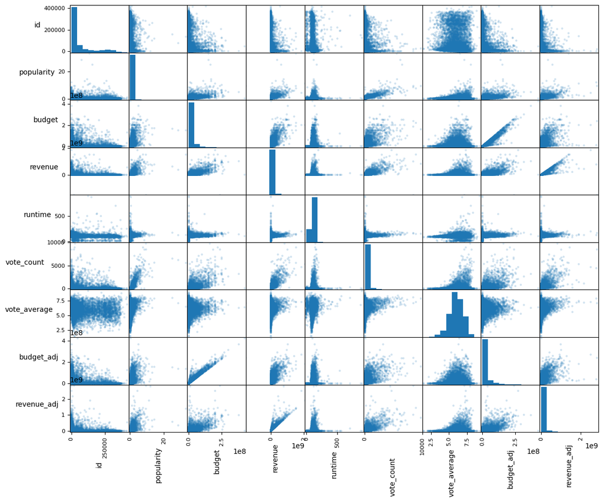

```python
# Create scatter matrix to check for possible correlations. This may return a RuntimeWarning. The code will still run, though.
axes = pd.plotting.scatter_matrix(df, alpha=0.2, figsize=(12, 10))
for ax in axes.flatten():
    ax.xaxis.label.set_rotation(90)
    ax.yaxis.label.set_rotation(0)
    ax.yaxis.label.set_ha('right')

plt.tight_layout()
plt.gcf().subplots_adjust(wspace=0, hspace=0)
plt.show()
```

```python
# Check for revenue values less than 0
df.query('revenue < 0')
```

|  | id | popularity | budget | revenue | original_title | director | runtime | genres | release_date | vote_count | vote_average | budget_adj | revenue_adj |
| --- | --- | --- | --- | --- | --- | --- | --- | --- | --- | --- | --- | --- | --- |
| 1386 | 19995 | 9.429688 | 237000000 | -1513461449 | Avatar | James Cameron | 162 | Action\|Adventure\|Fantasy\|Science Fiction | 2009-12-10 | 8458 | 7.101562 | 240886896.0 | 2.827124e+09 |

> It seems that this is the cause of the problem. James Cameron's "Avatar" seems to have a negative revenue. This also doesn't seem to be a separate "Avatar" entry with the wrong value in place, as seen below.

```python
df.query('original_title == "Avatar"')
```

|  | id | popularity | budget | revenue | original_title | director | runtime | genres | release_date | vote_count | vote_average | budget_adj | revenue_adj |
| --- | --- | --- | --- | --- | --- | --- | --- | --- | --- | --- | --- | --- | --- |
| 1386 | 19995 | 9.429688 | 237000000 | -1513461449 | Avatar | James Cameron | 162 | Action\|Adventure\|Fantasy\|Science Fiction | 2009-12-10 | 8458 | 7.101562 | 240886896.0 | 2.827124e+09 |

> To fix the issue, we can simply set the revenue for the film to be equal to the adjusted revenue.

```python
df.loc[df['original_title'] == 'Avatar', 'revenue'] = df.query('original_title == "Avatar"')['revenue_adj']
```

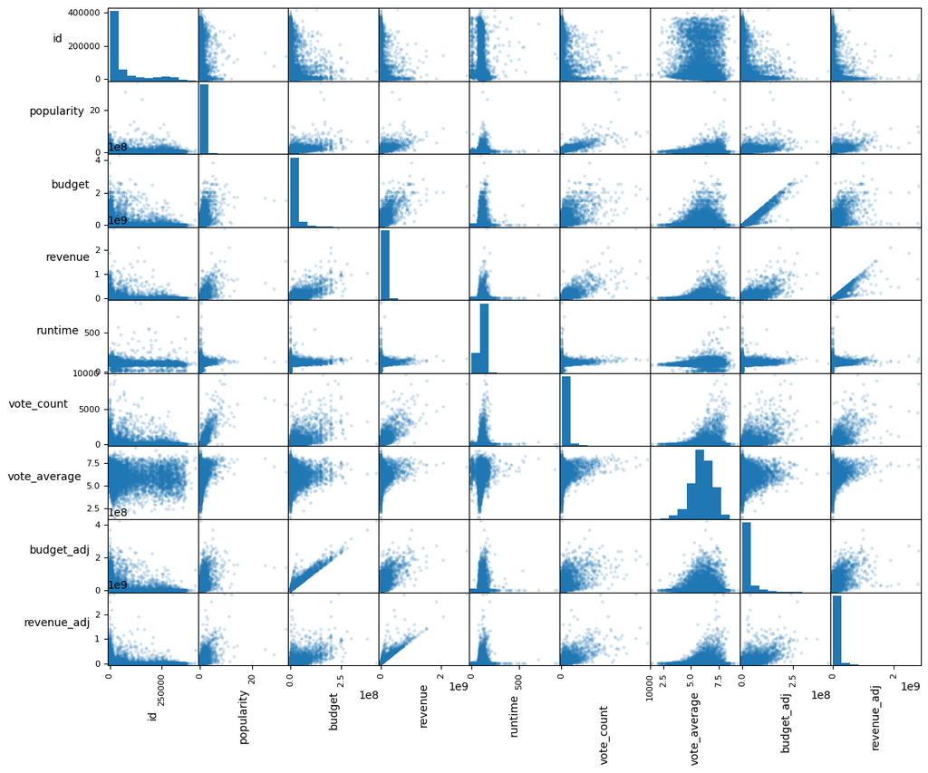

```python
# Rerun scatter_matrix code. No longer shows RuntimeWarning.
axes = pd.plotting.scatter_matrix(df, alpha=0.2, figsize=(12, 10))
for ax in axes.flatten():
    ax.xaxis.label.set_rotation(90)
    ax.yaxis.label.set_rotation(0)
    ax.yaxis.label.set_ha('right')

plt.tight_layout()
plt.gcf().subplots_adjust(wspace=0, hspace=0)
plt.show()
```

> Now that there aren't any revenue values below 0, we no longer get a RuntimeWarning, and the graphs for revenue no longer start in the middle. However, there are still many entries with 0 revenue or budget, so no is the time to create a new dataset without those values.

```python
# Creating separate dataframe without the 0 values
df_no_zero = df[df['revenue'] != 0]
df_no_zero = df_no_zero[df_no_zero['budget'] != 0]
df_no_zero.info()
```

```
<class 'pandas.core.frame.DataFrame'>
Index: 3853 entries, 0 to 10848
Data columns (total 13 columns):
 #   Column          Non-Null Count  Dtype
---  ------          --------------  -----
 0   id              3853 non-null   int32
 1   popularity      3853 non-null   float16
 2   budget          3853 non-null   int32
 3   revenue         3853 non-null   float64
 4   original_title  3853 non-null   object
 5   director        3853 non-null   object
 6   runtime         3853 non-null   int16
 7   genres          3853 non-null   string
 8   release_date    3853 non-null   datetime64[ns]
 9   vote_count      3853 non-null   int16
 10  vote_average    3853 non-null   float16
 11  budget_adj      3853 non-null   float32
 12  revenue_adj     3853 non-null   float32
dtypes: datetime64[ns](1), float16(2), float32(2), float64(1), int16(2), int32(2), object(2), string(1)
memory usage: 270.9+ KB
```

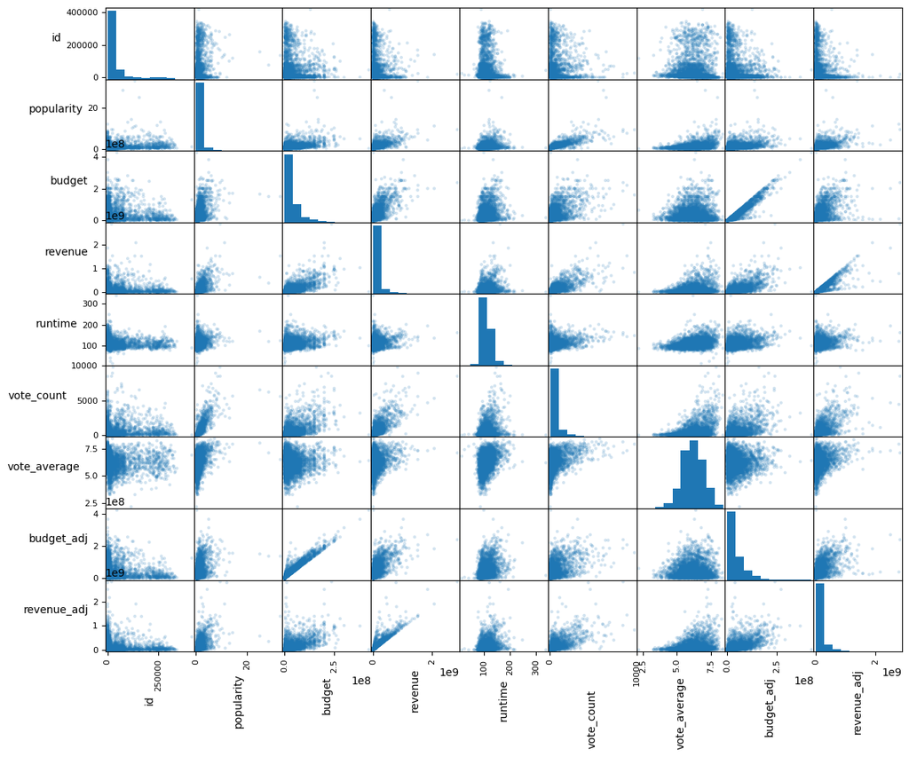

```python
axes = pd.plotting.scatter_matrix(df_no_zero, alpha=0.2, figsize=(12, 10))
for ax in axes.flatten():
    ax.xaxis.label.set_rotation(90)
    ax.yaxis.label.set_rotation(0)
    ax.yaxis.label.set_ha('right')

plt.tight_layout()
plt.gcf().subplots_adjust(wspace=0, hspace=0)
plt.show()
```

> Some data seems to have shifted, but most of it seems fairly similar. However, the size of the no_zero dataset is significantly less, only containing a little under 4000 rows.

## Exploratory Data Analysis

### How have revenue and budget changed over the years?

```python
# Use this, and more code cells, to explore your data. Don't forget to add
#   Markdown cells to document your observations and findings.

# Find the time window for analysis
print(df['release_date'].min(), df['release_date'].max())
df.info()
```

```
1960-01-01 00:00:00 2015-12-31 00:00:00
<class 'pandas.core.frame.DataFrame'>
Index: 10800 entries, 0 to 10865
Data columns (total 13 columns):
 #   Column          Non-Null Count  Dtype
---  ------          --------------  -----
 0   id              10800 non-null  int32
 1   popularity      10800 non-null  float16
 2   budget          10800 non-null  int32
 3   revenue         10800 non-null  float64
 4   original_title  10800 non-null  object
 5   director        10800 non-null  object
 6   runtime         10800 non-null  int16
 7   genres          10800 non-null  string
 8   release_date    10800 non-null  datetime64[ns]
 9   vote_count      10800 non-null  int16
 10  vote_average    10800 non-null  float16
 11  budget_adj      10800 non-null  float32
 12  revenue_adj     10800 non-null  float32
dtypes: datetime64[ns](1), float16(2), float32(2), float64(1), int16(2), int32(2), object(2), string(1)
memory usage: 759.4+ KB
```

> Revenue seems to have been reverted to a float64 after that last calculation, so I need to change it back.

```python
typing_mask = lowest_num(df)
df = df.astype(typing_mask)
df_no_zero = df[df['revenue'] != 0]
df_no_zero = df_no_zero[df_no_zero['budget'] != 0]
```

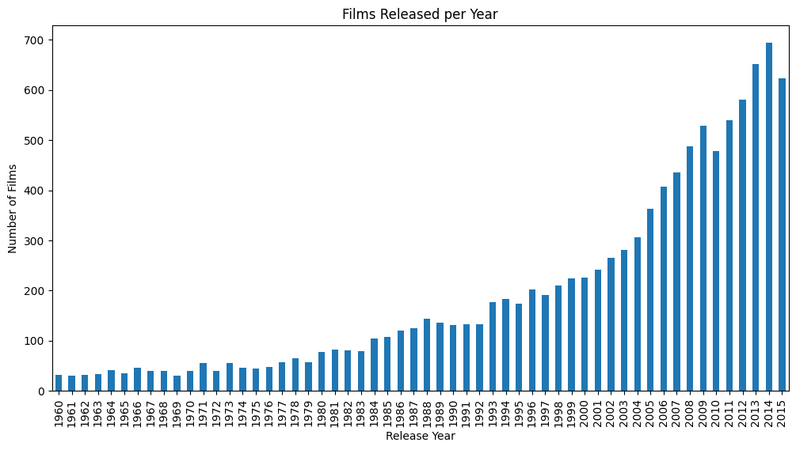

```python
df['release_date'].dt.year.value_counts().sort_index().plot(kind='bar', figsize=(12, 6), title="Films Released per Year", xlabel="Release Year", ylabel="Number of Films")
```

> The number of films per year seems to increase in the dataset. However, it is entirely possible that this is due to the dataset being incomplete, and only having significant data for more recent years.

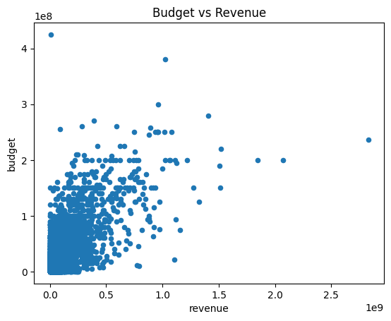

```python
df.plot(x='revenue', y='budget', kind='scatter', title="Budget vs Revenue")
```

> There appears to be a positive correlation between revenue and budget. However, this correlation seems fairly weak.

```python
# Define functions for more easily creating various graphs for release_date, budget, and revenue from defined dataframe. Could be modified to
# accept any graph by creating x and y arguments and adding more graph types to the function. Second and third function work together to
# create two seperate graphs for both revenue and budget.

def quick_graph(data, graph, sep=False, x='release_date', y=['revenue', 'budget']):
    if not sep:
        ax = data.plot(alpha=0.5, x=x, y=y[0], kind=graph, color='Blue', label=y[0], figsize=(10, 4))
        if len(y) > 1:
            data.plot(alpha=0.5, x=x, y=y[1], kind=graph, color='Red', label=y[1], ax=ax, figsize=(10, 4))
            ax.legend(loc='upper right')
    else:
        data.plot(alpha=0.5, x=x, y=y[0], kind=graph, color='Blue', label=y[0], figsize=(10, 4), title=f"{y[0]} over {x}")
        if len(y) > 1:
            data.plot(alpha=0.5, x=x, y=y[1], kind=graph, color='Red', label=y[1], figsize=(10, 4), title=f"{y[1]} over {x}")
            plt.show()


def tend_graph(data, tend, fieldname, color='Blue', group='release_date'):
    if group == 'release_date':
        if tend == 'mean':
            data.groupby(pd.Grouper(key=group, freq='YE'))[fieldname].mean().plot(kind='line', color=color, label=fieldname, figsize=(10, 4), legend=True)
        if tend == 'median':
            data.groupby(pd.Grouper(key=group, freq='YE'))[fieldname].median().plot(kind='line', color=color, label=fieldname, figsize=(10, 4), legend=True)
    else:
        if tend == 'mean':
            data.groupby(by=group)[fieldname].mean().plot(kind='line', color=color, label=fieldname, figsize=(10, 4), legend=True)
        if tend == 'median':
            data.groupby(by=group)[fieldname].median().plot(kind='line', color=color, label=fieldname, figsize=(10, 4), legend=True)


def quick_line(data, tend, fields=['revenue', 'budget']):
    tend_graph(data, tend, fields[0], color='Blue')
    tend_graph(data, tend, fields[1], color='Red')
```

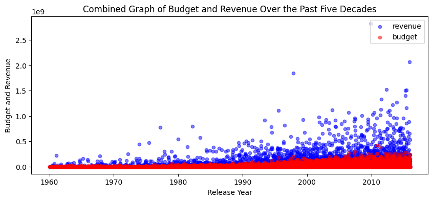

```python
quick_graph(df, 'scatter')
plt.ylabel("Budget and Revenue")
plt.xlabel("Release Year")
plt.title("Combined Graph of Budget and Revenue Over the Past Five Decades");
```

> As seen by these two graphs, with or without the zero values, budget and revenue appear to be increasing over time. Or at least, the maximum of both seems to increase. The minimum seems to largely stay the same.

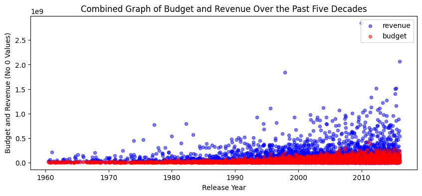

```python
quick_graph(df_no_zero, graph='scatter')
plt.ylabel("Budget and Revenue (No 0 Values)")
plt.xlabel("Release Year")
plt.title("Combined Graph of Budget and Revenue Over the Past Five Decades");
```

> Here are the two graphs separated for the non-zero set.

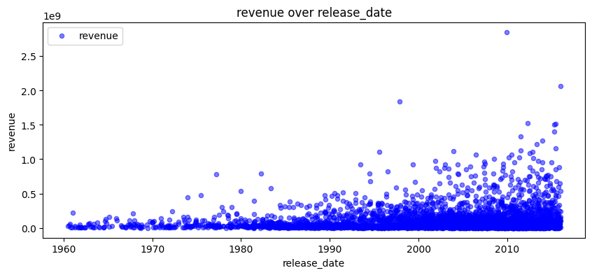

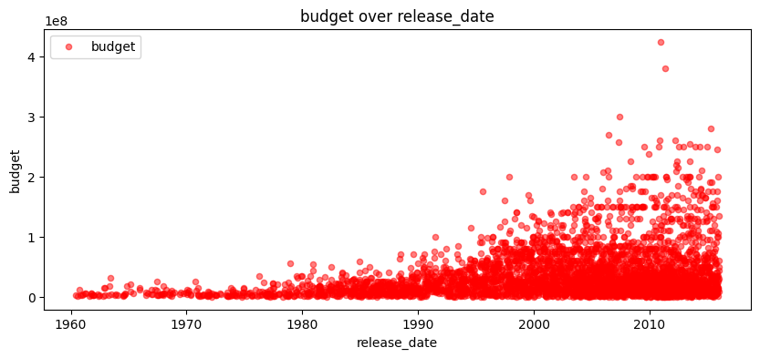

```python
quick_graph(df_no_zero, graph='scatter', sep=True)
```

> While separate, it appears that budget is increasing at a faster rate. However, the maximum value listed for budget is 1e8, while revenue is 1e9. That is an order of magnitude different, and looking at the graphs together rather than separate as done in the first two graphs shows this.

> Both revenue and budget have been increasing at a steady rate, and budget rate of increase seems to be higher than revenue. However, revenue still seems to be above budget, but that only appears to be the case if you look at the maximum values in the scatter graph, shown by the tops of the dense clusters. Looking at the mean, however, shows that they appear to have a tighter correlation, with both steadily increasing until around the year 2000, then seemingly starting to decrease.

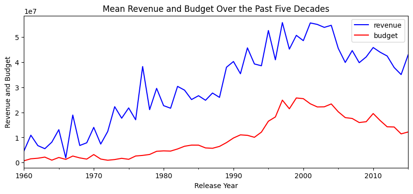

```python
quick_line(df, 'mean')
plt.xlabel("Release Year")
plt.ylabel("Revenue and Budget")
plt.title("Mean Revenue and Budget Over the Past Five Decades");
```

> This trend is only when zeros are in the dataset, and removing them shows that revenue continues to increase, and budget seems to flatten off.

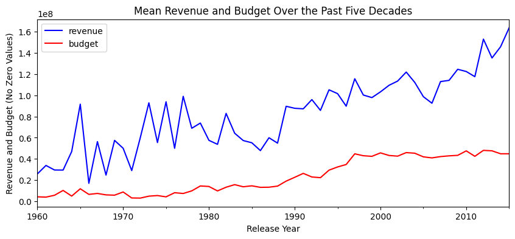

```python
quick_line(df_no_zero, 'mean')
plt.xlabel("Release Year")
plt.ylabel("Revenue and Budget (No Zero Values)")
plt.title("Mean Revenue and Budget Over the Past Five Decades");
```

> Using the median values shows a similar trend, though the graph with zeros doesn't really show any trend at all.

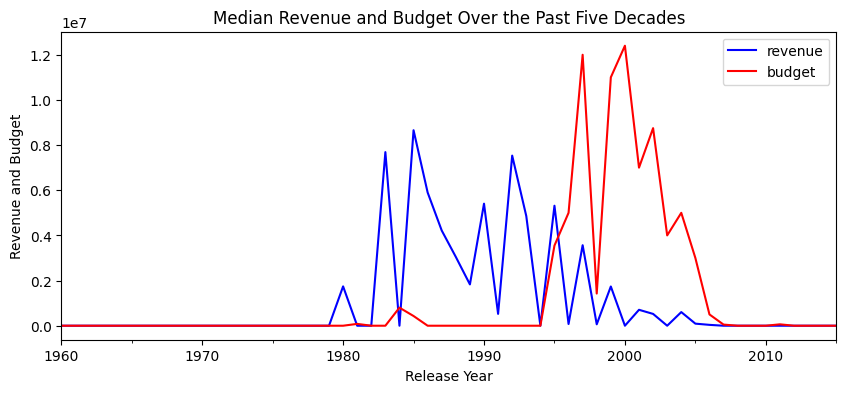

```python
quick_line(df, 'median')
plt.xlabel("Release Year")
plt.ylabel("Revenue and Budget")
plt.title("Median Revenue and Budget Over the Past Five Decades");
```

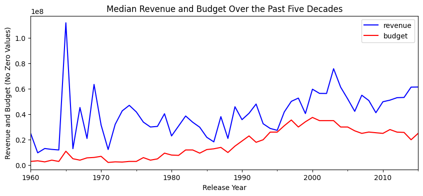

```python
quick_line(df_no_zero, 'median')
plt.xlabel("Release Year")
plt.ylabel("Revenue and Budget (No Zero Values)")
plt.title("Median Revenue and Budget Over the Past Five Decades");
```

> There appears to be an outlier early on in the median graph. What could that be about?

```python
print(df_no_zero.groupby(pd.Grouper(key='release_date', freq='YE'))['revenue'].median())
```

```
release_date
1960-12-31     25000000.0
1961-12-31      9750000.0
1962-12-31     13129846.0
1963-12-31     12439058.5
1964-12-31     12000000.0
1965-12-31    111721912.0
1966-12-31     13000000.0
1967-12-31     45300000.0
1968-12-31     21000000.0
1969-12-31     63379774.0
1970-12-31     31559552.0
1971-12-31     12348905.0
1972-12-31     32069323.0
1973-12-31     42661734.0
1974-12-31     47000000.0
1975-12-31     41833348.0
1976-12-31     33833200.0
1977-12-31     30000000.0
1978-12-31     30471420.0
1979-12-31     40399822.0
1980-12-31     23000000.0
1981-12-31     30794558.0
1982-12-31     38633534.0
1983-12-31     33759264.0
1984-12-31     29835023.0
1985-12-31     21930418.0
1986-12-31     18345040.0
1987-12-31     38120794.0
1988-12-31     21032268.0
1989-12-31     45892212.0
1990-12-31     35763604.0
1991-12-31     40784326.0
1992-12-31     48017400.0
1993-12-31     32558288.0
1994-12-31     28866943.0
1995-12-31     27400000.0
1996-12-31     41795444.0
1997-12-31     50113728.0
1998-12-31     52677198.0
1999-12-31     40554550.0
2000-12-31     59647802.0
2001-12-31     56359980.0
2002-12-31     56298472.0
2003-12-31     75715440.0
2004-12-31     61255920.0
2005-12-31     52034888.0
2006-12-31     42285168.0
2007-12-31     54926888.0
2008-12-31     50763612.0
2009-12-31     41212396.0
2010-12-31     49805168.0
2011-12-31     51070808.0
2012-12-31     52989688.0
2013-12-31     53181194.0
2014-12-31     61279452.0
2015-12-31     61365326.0
Freq: YE-DEC, Name: revenue, dtype: float64
```

```python
df_no_zero[df_no_zero['revenue'] == 111721912]
```

|  | id | popularity | budget | revenue | original_title | director | runtime | genres | release_date | vote_count | vote_average | budget_adj | revenue_adj |
| --- | --- | --- | --- | --- | --- | --- | --- | --- | --- | --- | --- | --- | --- |
| 10691 | 907 | 1.282227 | 14000000 | 111721912.0 | Doctor Zhivago | David Lean | 197 | Drama\|Romance\|War | 1965-12-22 | 126 | 6.898438 | 96887888.0 | 773178624.0 |

> I have never heard of this film, but I guess 1965 was a good year for movies. Actually, only 5 movies from that year are in the dataset, so using central tendency values for this year may produce outliers when mixed with other years that have many more entries. By grouping by year, we can see a count of how many films the dataset has for each year, and we can see that later years have more films per year. This does not necessarily mean that more films get released each year, though that is a possibility, but it could also mean that this dataset is incomplete, and only has extensive data for more recent years. This trend is also seen in the histogram above.

```python
print(df_no_zero.groupby(pd.Grouper(key='release_date', freq='YE'))['revenue'].count())
print()
print(df.groupby(pd.Grouper(key='release_date', freq='YE'))['revenue'].count())
```

```
release_date
1960-12-31      5
1961-12-31     10
1962-12-31      7
1963-12-31      6
1964-12-31      7
1965-12-31      5
1966-12-31      5
1967-12-31     13
1968-12-31      9
1969-12-31      4
1970-12-31     11
1971-12-31     13
1972-12-31      8
1973-12-31     12
1974-12-31     13
1975-12-31      9
1976-12-31     15
1977-12-31     19
1978-12-31     17
1979-12-31     16
1980-12-31     23
1981-12-31     30
1982-12-31     26
1983-12-31     31
1984-12-31     42
1985-12-31     41
1986-12-31     48
1987-12-31     46
1988-12-31     57
1989-12-31     51
1990-12-31     53
1991-12-31     50
1992-12-31     53
1993-12-31     72
1994-12-31     62
1995-12-31     81
1996-12-31     86
1997-12-31     90
1998-12-31     92
```

[output cut: 62 more lines]

```
2002-12-31    266
2003-12-31    281
2004-12-31    307
2005-12-31    363
2006-12-31    408
2007-12-31    435
2008-12-31    488
2009-12-31    528
2010-12-31    479
2011-12-31    539
2012-12-31    581
2013-12-31    652
2014-12-31    694
2015-12-31    624
Freq: YE-DEC, Name: revenue, dtype: int64
```

```python
df_no_zero[df_no_zero['release_date'].dt.year == 1965]
```

|  | id | popularity | budget | revenue | original_title | director | runtime | genres | release_date | vote_count | vote_average | budget_adj | revenue_adj |
| --- | --- | --- | --- | --- | --- | --- | --- | --- | --- | --- | --- | --- | --- |
| 10689 | 660 | 1.910156 | 11000000 | 141195664.0 | Thunderball | Terence Young | 130 | Adventure\|Action\|Thriller | 1965-12-16 | 331 | 6.300781 | 76126200.0 | 9.771535e+08 |
| 10690 | 15121 | 1.313477 | 8200000 | 163214288.0 | The Sound of Music | Robert Wise | 174 | Drama\|Family\|Music\|Romance | 1965-03-02 | 620 | 7.199219 | 56748624.0 | 1.129535e+09 |
| 10691 | 907 | 1.282227 | 14000000 | 111721912.0 | Doctor Zhivago | David Lean | 197 | Drama\|Romance\|War | 1965-12-22 | 126 | 6.898438 | 96887888.0 | 7.731786e+08 |
| 10692 | 10338 | 0.622070 | 5600000 | 29950000.0 | Those Magnificent Men in Their Flying Machines... | Ken Annakin | 138 | Action\|Adventure\|Comedy | 1965-06-03 | 19 | 6.601562 | 38755156.0 | 2.072709e+08 |
| 10716 | 2428 | 0.145996 | 20000000 | 12000000.0 | The Greatest Story Ever Told | George Stevens | 199 | Drama\|History | 1965-02-15 | 13 | 5.699219 | 138411280.0 | 8.304677e+07 |

```python
df_no_zero[df_no_zero['release_date'].dt.year == 1965].describe()
```

|  | id | popularity | budget | revenue | runtime | release_date | vote_count | vote_average | budget_adj | revenue_adj |
| --- | --- | --- | --- | --- | --- | --- | --- | --- | --- | --- |
| count | 5.000000 | 5.000000 | 5.000000e+00 | 5.0 | 5.0000 | 5 | 5.00000 | 5.000000 | 5.0 | 5.000000e+00 |
| mean | 5890.800000 | 1.054688 | 1.176000e+07 | 91616368.0 | 167.6000 | 1965-07-12 09:36:00 | 221.80000 | 6.539062 | 81385832.0 | 6.340369e+08 |
| min | 660.000000 | 0.145996 | 5.600000e+06 | 12000000.0 | 130.0000 | 1965-02-15 00:00:00 | 13.00000 | 5.699219 | 38755156.0 | 8.304677e+07 |
| 25% | 907.000000 | 0.622070 | 8.200000e+06 | 29950000.0 | 138.0000 | 1965-03-02 00:00:00 | 19.00000 | 6.300781 | 56748624.0 | 2.072709e+08 |
| 50% | 2428.000000 | 1.282227 | 1.100000e+07 | 111721912.0 | 174.0000 | 1965-06-03 00:00:00 | 126.00000 | 6.601562 | 76126200.0 | 7.731786e+08 |
| 75% | 10338.000000 | 1.313477 | 1.400000e+07 | 141195664.0 | 197.0000 | 1965-12-16 00:00:00 | 331.00000 | 6.898438 | 96887888.0 | 9.771535e+08 |
| max | 15121.000000 | 1.910156 | 2.000000e+07 | 163214288.0 | 199.0000 | 1965-12-22 00:00:00 | 620.00000 | 7.199219 | 138411280.0 | 1.129535e+09 |
| std | 6503.166436 | 0.682617 | 5.570278e+06 | 67324048.0 | 32.3311 | NaN | 257.09473 | 0.576660 | 38549468.0 | 4.659203e+08 |

> Just for fun, let's see how profit has changed over the years as well.

```python
df['profit'] = df['revenue'] - df['budget']
df_no_zero['profit'] = df_no_zero['revenue'] - df_no_zero['budget']
```

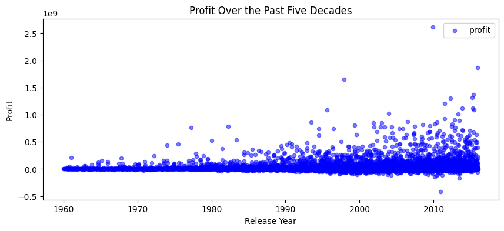

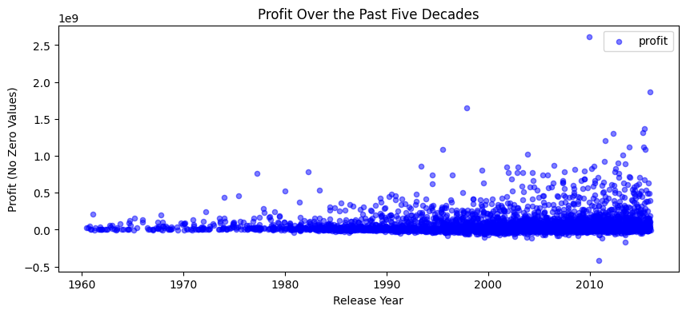

```python
quick_graph(df, graph='scatter', y=['profit'])
plt.xlabel("Release Year")
plt.ylabel("Profit")
plt.title("Profit Over the Past Five Decades")
quick_graph(df_no_zero, graph='scatter', y=['profit'])
plt.xlabel("Release Year")
plt.ylabel("Profit (No Zero Values)")
plt.title("Profit Over the Past Five Decades");
```

```
Red line is mean profits without zeros.
Blue line is with.
```

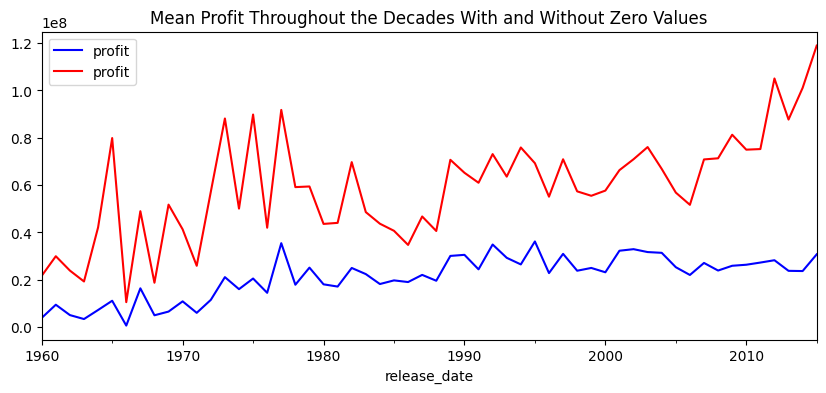

```
Orange line is median profits without zeros.
Green line is with.
```

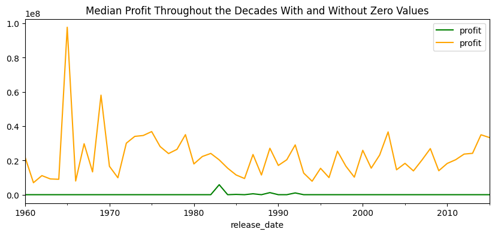

```python
tend_graph(df, 'mean', 'profit', 'Blue')
tend_graph(df_no_zero, 'mean', 'profit', 'Red')
plt.title("Mean Profit Throughout the Decades With and Without Zero Values")
print('Red line is mean profits without zeros. \nBlue line is with.')
plt.show()
print('Orange line is median profits without zeros. \nGreen line is with.')
tend_graph(df, 'median', 'profit', 'Green')
tend_graph(df_no_zero, 'median', 'profit', 'Orange')
plt.title("Median Profit Throughout the Decades With and Without Zero Values");
```

### Question 1 conclusion:

> Both budget and revenue have increased over time, though since revenue seems to have been increasing at a faster rate, total profits have also been slightly increasing over time, as seen in the final graph. However, while mean profits seem to increase significantly, median profits largely seem to stay the same. Outliers and large spikes early on in the graphs are likely from years with few films, all or most of which did fairly well. Using central tendency with few data points tends to make it harder to show accurate trends over time, but a general trend can still be seen.

### How does genre affect popularity?

> To start, we should probably scale down the dataset, since there is only one 'genres' column, but mutiple genres per film. As such, I am going to split the 'genres' column to account for all of the genres. The fact that each cell in the column contains a set of various different genres is probably why there are so many unique values in the column.

```python
# Let's start by showing the columns to decide which to get rid of in the new dataset.
df.head(1)
```

|  | id | popularity | budget | revenue | original_title | director | runtime | genres | release_date | vote_count | vote_average | budget_adj | revenue_adj | profit |
| --- | --- | --- | --- | --- | --- | --- | --- | --- | --- | --- | --- | --- | --- | --- |
| 0 | 135397 | 33.0 | 150000000 | 1.513529e+09 | Jurassic World | Colin Trevorrow | 124 | Action\|Adventure\|Science Fiction\|Thriller | 2015-06-09 | 5562 | 6.5 | 137999936.0 | 1.392446e+09 | 1.363529e+09 |

```python
# We don't need most of these. 'id' will be kept, as having a primary key is almost always a good idea for a table, but most of these can go.
drop_columns = ['budget', 'runtime', 'vote_count', 'vote_average', 'budget_adj', 'revenue_adj', 'profit']
df_genres = df.drop(drop_columns, axis=1)
```

```python
df_genres.head(1)
```

|  | id | popularity | revenue | original_title | director | genres | release_date |
| --- | --- | --- | --- | --- | --- | --- | --- |
| 0 | 135397 | 33.0 | 1.513529e+09 | Jurassic World | Colin Trevorrow | Action\|Adventure\|Science Fiction\|Thriller | 2015-06-09 |

```python
# Split each string value in the column to a list of strings
df_genres['genres'] = df_genres['genres'].str.split(pat='|').to_list()
```

```python
df_genres.head(1)
```

|  | id | popularity | revenue | original_title | director | genres | release_date |
| --- | --- | --- | --- | --- | --- | --- | --- |
| 0 | 135397 | 33.0 | 1.513529e+09 | Jurassic World | Colin Trevorrow | [Action, Adventure, Science Fiction, Thriller] | 2015-06-09 |

```python
# Split each list in the column to create multiple rows for each entry, each with a single genre
df_genres = df_genres.explode(column='genres')
```

```python
df_genres.info()
```

```
<class 'pandas.core.frame.DataFrame'>
Index: 26864 entries, 0 to 10865
Data columns (total 7 columns):
 #   Column          Non-Null Count  Dtype
---  ------          --------------  -----
 0   id              26864 non-null  int32
 1   popularity      26864 non-null  float16
 2   revenue         26864 non-null  float32
 3   original_title  26864 non-null  object
 4   director        26864 non-null  object
 5   genres          26864 non-null  object
 6   release_date    26864 non-null  datetime64[ns]
dtypes: datetime64[ns](1), float16(1), float32(1), int32(1), object(3)
memory usage: 1.3+ MB
```

```python
df_genres['genres'].nunique()
```

```
20
```

> Now that there are only 20 unique genre values, changing it to type category should decrease the size.

```python
df_genres['genres'].memory_usage()
```

```
429824
```

```python
df_genres = df_genres.astype({'genres': 'category'})
```

```python
df_genres['genres'].memory_usage()
```

```
242492
```

> With the new low cardinality, changing 'genres' to category nearly halved the field's size.

```python
print(df_genres['genres'].nunique())
print(df_genres['genres'].value_counts())
```

```
20
genres
Drama              4754
Comedy             3782
Thriller           2904
Action             2378
Romance            1708
Horror             1636
Adventure          1466
Crime              1353
Science Fiction    1223
Family             1223
Fantasy             912
Mystery             809
Animation           692
Documentary         509
Music               402
History             332
War                 270
Foreign             185
Western             164
TV Movie            162
Name: count, dtype: int64
```

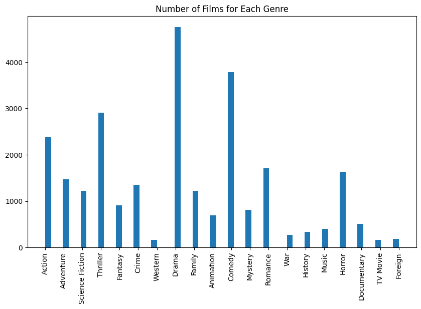

```python
# This is the closest I could get the histogram's bars to line up with the labels. Having bins='stone' or 'sqrt' will also work, but the bars become
# much smaller.
df_genres['genres'].hist(figsize=(10, 6), xrot=90, align='mid', bins='rice', grid=False)
plt.title("Number of Films for Each Genre");
```

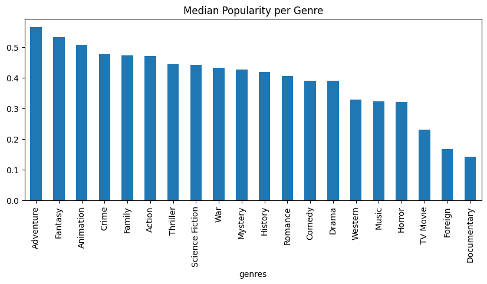

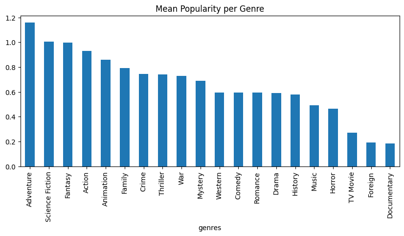

```python
df_genres.groupby(by='genres', observed=False)['popularity'].median().sort_values(ascending=False).plot(kind='bar', figsize=(10, 4), title='Median Popularity per Genre')
plt.show()
df_genres.groupby(by='genres', observed=False)['popularity'].mean().sort_values(ascending=False).plot(kind='bar', figsize=(10, 4), title='Mean Popularity per Genre');
```

> The order changes slightly depending on whether mean or median is used. To clarify, median can help to remove the influence of outliers in datasets. You can see this skew in the graphs, as the mean graph goes up to 1.2, while the median graph only goes up to 0.5. There is a way to check for outliers.

```python
Q1 = df_genres['popularity'].quantile(0.25)
Q3 = df_genres['popularity'].quantile(0.75)
iqr = Q3-Q1

df_genre_outliers = df_genres[(df_genres['popularity'] < (Q1 - 1.5 * iqr)) | (df_genres['popularity'] > (Q3 + 1.5 * iqr))]
```

```python
df_genre_outliers['genres'].value_counts()
```

```
genres
Action             333
Adventure          293
Drama              276
Comedy             250
Thriller           250
Science Fiction    184
Fantasy            159
Family             151
Romance            119
Crime              117
Animation          108
Mystery             62
Horror              51
War                 30
Music               22
History             19
Western              7
TV Movie             1
Foreign              0
Documentary          0
Name: count, dtype: int64
```

> It seems that various genres have some outliers. However, the genres with the most outliers also are also genres with a lot of entries in the dataset. In order to see how much the outliers affect the mean of each genre, more work needs to be done.

```python
df_out_neg = df_genres[(df_genres['popularity'] < (Q1 - 1.5 * iqr))]
df_out_pos = df_genres[(df_genres['popularity'] > (Q3 + 1.5 * iqr))]
print(100 * (df_out_pos['genres'].value_counts()) / (df_genres['genres'].value_counts()))
print(100 * (df_out_neg['genres'].value_counts()) / (df_genres['genres'].value_counts()))
```

```
genres
Action             14.003364
Adventure          19.986357
Animation          15.606936
Comedy              6.610259
Crime               8.647450
Documentary         0.000000
Drama               5.805637
Family             12.346688
Fantasy            17.434211
Foreign             0.000000
History             5.722892
Horror              3.117359
Music               5.472637
Mystery             7.663782
Romance             6.967213
Science Fiction    15.044971
TV Movie            0.617284
Thriller            8.608815
War                11.111111
Western             4.268293
Name: count, dtype: float64
genres
Action             0.0
Adventure          0.0
Animation          0.0
Comedy             0.0
Crime              0.0
Documentary        0.0
Drama              0.0
Family             0.0
Fantasy            0.0
Foreign            0.0
History            0.0
Horror             0.0
Music              0.0
Mystery            0.0
Romance            0.0
Science Fiction    0.0
TV Movie           0.0
Thriller           0.0
War                0.0
Western            0.0
Name: count, dtype: float64
```

> Seemingly, there aren't any outliers bringing down the mean, but some genres are nearly 20% outliers. However, the actual number of outliers seems to affect the mean more than the percent of data that is outliers. Looking at the percentages and the above graphs does not seem to explain the difference between mean and median, as the genres with high percentages don't necessarily lower in popularity from mean to median, with some of them even increasing in rank. When looking at the flat number of outliers, genres with more are more likely to have a higher mean compared to the median.

```python
df_genre_no_zero = df_genres[df_genres['revenue'] != 0]
```

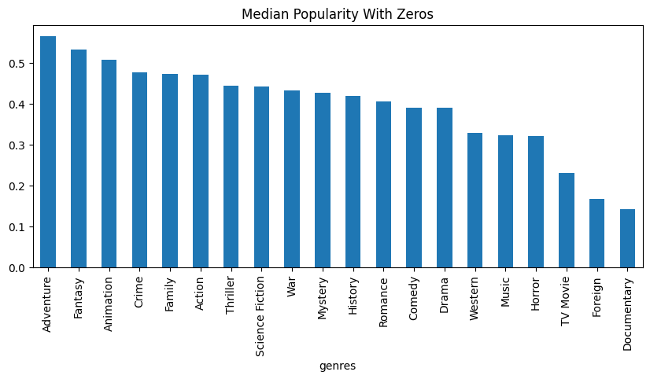

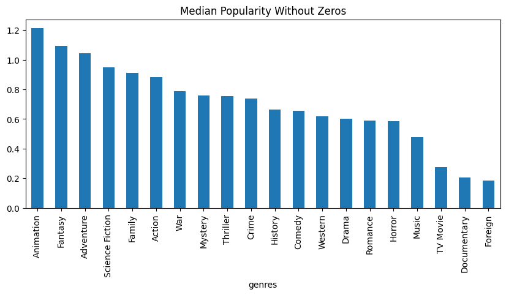

```python
df_genres.groupby(by='genres', observed=False)['popularity'].median().sort_values(ascending=False).plot(kind='bar', figsize=(10, 4), title='Median Popularity With Zeros')
plt.show()
df_genre_no_zero.groupby(by='genres', observed=False)['popularity'].median().sort_values(ascending=False).plot(kind='bar', figsize=(10, 4), title='Median Popularity Without Zeros');
```

### Question 2 Conclusion

> Animation, Fantasy, and Adventure seem to be the most popular genres, while Foreign, Documentary, and TV Movies seem to be the least popular.

## Conclusions

### Question 1: How have revenue and budget changed over the years?

> Both budget and revenue, between the years 1960 and 2015, have largely increased, with revenue incresing at a faster rate, so overall mean profits have increased over time. However, median profits have not changed much. Importantly, it is highly likely that the dataset is incomplete, as I stated during the exploration portion, leading to more jagged graphs that may be harder to discern accurate trends.

### Question 2: How does genre affect popularity?

> Adventure, Animation, and Fantasy films tend to be the most popular, while TV Movies, Documentary, and Foreign films tend to be the least popular.  
> However, as stated before, the dataset seems to be incomplete, making accurate analysis difficult. Also, most genres don't really have a rigid definition, so while two films may be labeled as "Fantasy", the actual content of each may be vastly different. For example, "Star Wars" and "The Lord of the Rings" are both "fantasy", but one is high fantasy, while the other is sci-fi. Due to the nebulous definition of each genre, while one can see how popular each genre is, it is far more difficult to determin how popular a film will be just from the listed genres.

## Limitations

> As stated above, the primary limitations are as follows: incomplete data and undefined genres. Because of these two factors, drawing conclusions outside of what has already been stated is difficult. Namely, while correlation can be seen, determining causation is far more difficult, and with the current dataset and the questions I chose to explore and the ways I chose to explore them, no causation can be implied.

```python
# Running this cell will execute a bash command to convert this notebook to an .html file
!python -m nbconvert --to html Investigate_a_Dataset.ipynb
```

```
[NbConvertApp] Converting notebook Investigate_a_Dataset.ipynb to html
[NbConvertApp] WARNING | Alternative text is missing on 22 image(s).
[NbConvertApp] Writing 3273299 bytes to Investigate_a_Dataset.html
```